# Zunqiu_Wang_ngs_week10_hw

Zunqiu Wang

3/27/2021

# Task 1: Create a DESeqDataSet object

Q1.1. Report the output indicating what type of object the dds variable is, how many genes, and how many samples are stored in the object? [ 1 point ]

- class: DESeqDataSet
- genes: 28595
- samples: 8

# Task 2: Pre-filter low count genes, normalize counts and run DESeq

Q2.1 Enter dds at the console to summarize your object. Report the output for your answer and how many genes were retained after removing the low count genes [ 1 point ].

class: DESeqDataSet dim: 20029 8 metadata(1): version assays(4): counts mu H cooks rownames(20029): Pdac_HC_000007FG0000100 Pdac_HC_000007FG0000200 … Pdac_HC_chr9G0154800 Pdac_HC_chr9G0155000 rowData names(22): baseMean baseVar … deviance maxCooks colnames(8): PDAC253.htseq_count.txt PDAC282.htseq_count.txt … PDAC306.htseq_count.txt PDAC318.htseq_count.txt colData names(2): condition sizeFactor

- 20029 genes retained

# Task 3: Analyze DGE data

Q3.1 Include the hierarchical clustering result, your plotPCA command, and the PCA plot for you answer [ 1 point ].

```r
dists <- dist(t(assay(rld)))
hclust(dists)
```

- Call: hclust(d = dists)

Cluster method : complete Distance : euclidean Number of objects: 8

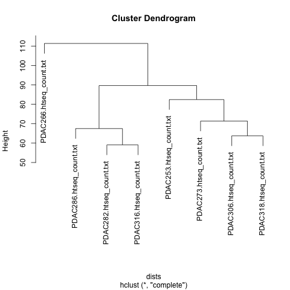

hcluster

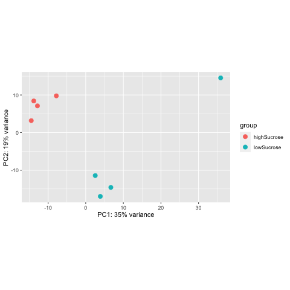

PCA

```r
plotPCA(rld, intgroup=c("condition"))
```

Q3.2a Do the samples cluster by sugar composition phenotype in the hierarchical clustering? Explain.

- mostly yes
- exception is one outlier sample PDAC266 from low sucrose group with abnormal long distance
- PDAC253, which originates from high sucrose group, is clustered within low sucrose group

Q3.2b Does the PCA separate samples by sugar composition? If so, on which axis?

- c

3.2c In many contexts, the treatment will induce large effects on the transcriptome that often cause biological replicates from the same treatment to cluster together. Another factor that could cause samples to cluster together is batch effects. Which of the following are potential sources of batch effects in RNA-seq analysis?

- f

Q3.2d Without any additional information about how the experiment was conducted, do you see any evidence of a batch effect? Why or why not?

- I think so
- PDAC253(high sucrose) is somehow incorrectly clustered within low sucrose group; PDAC266 is abnormally positioned out of clustering group
- sample maybe contaminated, or actually from high sucrose group(incorrectly assigned to the wrong group)

Q3.3 Read the section “More information on results columns” of the DESeq2 vignette and describe three quality control steps that are automatically conducted by DESeq to drop from consideration genes with suspect, or problematic, p-values How many genes were impacted by the default independent filtering? [ 1 point ].

- within a row all samples have zero counts sets pvalue to NA
- samples have extreme count outlier sets pvalue to NA
- low mean normalized count only affects padj, setting to NA

metadata(res)$filterThreshold 13.57143% are affected

```r
sum(is.na(resOrdered$pvalue))
```

- 199 genes are filtered in pvalue(NA)

Q3.4a. Report the table of results for the three candidate genes. For each of the candidate genes, which sugar-type (high sucrose or low sucrose) has higher expression? What is fold-change expressed on the decimal scale (convert from log2 to linear scale)? [ 1 point ]

```r
resOrdered_df_genes_intest <- resOrdered[ row.names(resOrdered) %in% c('Pdac_HC_chr14G0022900','Pdac_HC_chr14G0023100','Pdac_HC_chr14G0028200'), ]
```

```r
read.table("3 gene results table.csv", header = T, sep = " ")
```

```
##                        baseMean log2FoldChange     lfcSE     stat       pvalue
## Pdac_HC_chr14G0023100 2915.8578      5.6533911 0.6305094 8.966387 3.063990e-19
## Pdac_HC_chr14G0022900 2839.3198      9.9788138 1.2054300 8.278219 1.250307e-16
## Pdac_HC_chr14G0028200  590.0727      0.4296951 0.2496911 1.720907 8.526776e-02
##                               padj
## Pdac_HC_chr14G0023100 2.622929e-15
## Pdac_HC_chr14G0022900 4.281302e-13
## Pdac_HC_chr14G0028200 2.958450e-01
```

log2 fold change (MLE): condition lowSucrose vs highSucrose Wald test p-value: condition lowSucrose vs highSucrose

Q3.4b Sometimes its useful to report the normalized counts for each gene as a figure or table. For your answer, report the normalized counts for each candidate gene as a table [ 1 point ].

```r
read.table("Pdac_HC_chr14G0028200_counts_table.csv", header = T, sep = " ")
```

```
##                            count   condition
## PDAC253.htseq_count.txt 365.4494 highSucrose
## PDAC282.htseq_count.txt 544.6490 highSucrose
## PDAC286.htseq_count.txt 624.9751 highSucrose
## PDAC316.htseq_count.txt 475.6036 highSucrose
## PDAC266.htseq_count.txt 727.8490  lowSucrose
## PDAC273.htseq_count.txt 524.2659  lowSucrose
## PDAC306.htseq_count.txt 701.2766  lowSucrose
## PDAC318.htseq_count.txt 760.5131  lowSucrose
```

```r
read.table("Pdac_HC_chr14G0022900_counts_table.csv", header = T, sep = " ")
```

```
##                               count   condition
## PDAC253.htseq_count.txt    2.494259 highSucrose
## PDAC282.htseq_count.txt    2.086440 highSucrose
## PDAC286.htseq_count.txt   19.885037 highSucrose
## PDAC316.htseq_count.txt    0.500000 highSucrose
## PDAC266.htseq_count.txt 9441.867455  lowSucrose
## PDAC273.htseq_count.txt 6666.762989  lowSucrose
## PDAC306.htseq_count.txt 2941.984454  lowSucrose
## PDAC318.htseq_count.txt 3642.977490  lowSucrose
```

```r
read.table("Pdac_HC_chr14G0023100_counts_table.csv", header = T, sep = " ")
```

```
##                              count   condition
## PDAC253.htseq_count.txt   22.43685 highSucrose
## PDAC282.htseq_count.txt  106.79149 highSucrose
## PDAC286.htseq_count.txt  269.12122 highSucrose
## PDAC316.htseq_count.txt   57.73196 highSucrose
## PDAC266.htseq_count.txt 9356.85264  lowSucrose
## PDAC273.htseq_count.txt 6044.40094  lowSucrose
## PDAC306.htseq_count.txt 2713.47034  lowSucrose
## PDAC318.htseq_count.txt 4760.05711  lowSucrose
```

## I used lfcshrink with type=‘apeglm’ for following plot and analysis*****

Q3.5 Use the plotMA function to generate MA plots for the res and res.shrunk objects. Report the plots in your assignment document and explain your observations. Why it is appropriate to report the shrunken estimates. [ 1 point ].

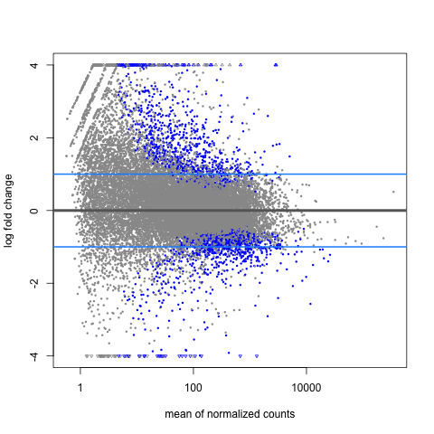

MA unshrunken

```r
plotMA(res, ylim=c(-4,4))
abline(h=c(-1,1), col="dodgerblue", lwd=2)
```

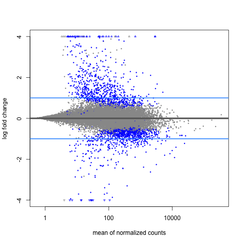

MA shrunken

```r
plotMA(res.shrunk, ylim=c(-4,4))
abline(h=c(-1,1), col="dodgerblue", lwd=2)
```

- Abundance of scatter for very low mean of normalized counts in unshrunken plot that exibits very high fold changes(overestimated); while fold change exhibits much smaller estimate after shrinkage
- Not interested in very lowly expressed genes, which could cause biased analysis and interpretation

# Task 4. The multiple testing problem

Q4.1 Subset the table with “shrunken” log2 fold-change estimates to include only the candidate genes and answer the following [ 1 point ]:

Q4.1a. Report your results from the lfcShrink output table for the candidate genes.

```r
res.shrunkOrdered_3_genes.table <- res.shrunkOrdered[ row.names(res.shrunkOrdered) %in% c('Pdac_HC_chr14G0022900','Pdac_HC_chr14G0023100','Pdac_HC_chr14G0028200'), ]
write.table(res.shrunkOrdered_3_genes.table, file = "/Users/zunqiuwang/Dropbox/NYU_Bioinfo/NGS/WK9/res.shrunkOrdered_3_genes.table.csv")
```

```r
read.table("res.shrunkOrdered_3_genes.table.csv", header = T, sep = " ")
```

```
##                        baseMean log2FoldChange     lfcSE       pvalue
## Pdac_HC_chr14G0023100 2915.8578      5.5142136 0.6389451 3.063990e-19
## Pdac_HC_chr14G0022900 2839.3198      9.6836921 1.2341344 1.250307e-16
## Pdac_HC_chr14G0028200  590.0727      0.3112794 0.2324078 8.526776e-02
##                               padj
## Pdac_HC_chr14G0023100 2.622929e-15
## Pdac_HC_chr14G0022900 4.281302e-13
## Pdac_HC_chr14G0028200 2.958450e-01
```

Q4.1b. Statisticians make the distinction between statistically signficant and biologically significant. Using a criterion that a statistically differentially expressed gene must also show at least a two-fold change in expression (on linear scale) to be biologically meaningful, which genes do you consider to be differentially expressed? Please specify the gene(s), the FDR threshold you applied.

```r
summary(res.shrunkOrdered_3_genes.table)
res.shrunkOrdered_3_genes.table[, "log2FoldChange">= 1]
keepabs <- abs(res.shrunkOrdered_3_genes.table$log2FoldChange) >=1
keepabs.df <- as.data.frame(res.shrunkOrdered_3_genes.table[keepabs,])
write.table(keepabs.df, file = "/Users/zunqiuwang/Dropbox/NYU_Bioinfo/NGS/WK9/keepabs.df.csv")
```

out of 3 with nonzero total read count adjusted p-value < 0.1 LFC > 0 (up) : 2, 67% LFC < 0 (down) : 0, 0% outliers [1] : 0, 0% low counts [2] : 0, 0% (mean count < 4) [1] see ‘cooksCutoff’ argument of ?results [2] see ‘independentFiltering’ argument of ?results

```r
read.table("keepabs.df.csv", header = T, sep = " ")
```

```
##                       baseMean log2FoldChange     lfcSE       pvalue
## Pdac_HC_chr14G0023100 2915.858       5.514214 0.6389451 3.063990e-19
## Pdac_HC_chr14G0022900 2839.320       9.683692 1.2341344 1.250307e-16
##                               padj
## Pdac_HC_chr14G0023100 2.622929e-15
## Pdac_HC_chr14G0022900 4.281302e-13
```

- after applying selected criteria(FDR<0.05, log2FoldChange>1), meaning 2-fold change in expression on linear scale, only 2 genes: Pdac_HC_chr14G0023100 Pdac_HC_chr14G0022900 are considered to be DGE.

Q4.1c Which of the candidate genes do you think could be responsible for the sugar composition trait on the chromosome 14 sugar QTL?

- Conclusion: Possibly, either of Pdac_HC_chr14G0023100 or Pdac_HC_chr14G0022900 or both could contribute to sugar composition trait. large log2 fold change and High expression leads to low sucrose. Most importantly, its p value/adjusted p value reveals significance.